# Lab 9

- Show All Code
- Hide All Code
- View Source

Author

Trenton Tadaki

```r
library(here)
library(tidyverse)
library(broom)
library(knitr)

StateNames_A <- read_csv(here('Week 9', 'Lab 9', 'StateNames_A.csv'))
```

## **3 Summarizing & Visualizing the Number of Allisons**

1. Make a summary table of the number of babies named “Allison” for each state and the sex of the baby. Specifically, the table should have the following qualities:
- each state should be its own row
- and each sex should have its own column
- if there were no babies born for that combination of state & sex there should be a 0 (not an `NA`)

```r
Allison_table <- StateNames_A |>
  filter(Name == 'Allison') |>
  rename(sex = Gender) |>
  group_by(sex, State) |>
  summarise(total_count = sum(Count)) |>
  pivot_wider(names_from = sex,
              values_from = total_count) |>
  replace_na(list('M' = 0,
             'F' = 0))

Allison_table |>
  kable(format = "html",
        col.names =
          c("State",
            "Females",
            "Males"),
        caption = "Number of Babies named 'Allison' in each State sorted by Sex")
```

Number of Babies named 'Allison' in each State sorted by Sex

| State | Females | Males |
| --- | --- | --- |
| AK | 232 | 0 |
| AL | 1535 | 0 |
| AR | 1198 | 0 |
| AZ | 1880 | 0 |
| CA | 12413 | 0 |
| CO | 1594 | 0 |
| CT | 1099 | 0 |
| DC | 321 | 0 |
| DE | 294 | 0 |
| FL | 4455 | 0 |
| GA | 3257 | 0 |
| HI | 183 | 0 |
| IA | 1477 | 0 |
| ID | 451 | 0 |
| IL | 5110 | 0 |
| IN | 3067 | 0 |
| KS | 1283 | 0 |
| KY | 1905 | 20 |
| LA | 1209 | 0 |
| MA | 2218 | 0 |
| MD | 2229 | 0 |
| ME | 340 | 0 |
| MI | 4014 | 0 |
| MN | 2374 | 0 |
| MO | 2882 | 0 |
| MS | 817 | 0 |
| MT | 226 | 0 |
| NC | 3435 | 0 |
| ND | 285 | 0 |
| NE | 807 | 0 |
| NH | 412 | 0 |
| NJ | 3052 | 0 |
| NM | 399 | 0 |
| NV | 729 | 0 |
| NY | 5747 | 0 |
| OH | 5487 | 0 |
| OK | 1421 | 0 |
| OR | 1186 | 0 |
| PA | 4307 | 0 |
| RI | 306 | 0 |
| SC | 1228 | 0 |
| SD | 376 | 0 |
| TN | 2488 | 0 |
| TX | 10192 | 0 |
| UT | 1125 | 0 |
| VA | 3220 | 0 |
| VT | 135 | 0 |
| WA | 1956 | 0 |
| WI | 2367 | 0 |
| WV | 813 | 0 |
| WY | 142 | 0 |

2. You should have seen in the above that “Allison” is a name given overwhelmingly to babies assigned “female” at birth. So, create a new dataset named `allison_f` which contains **only** the babies assigned `F`emale at birth.

```r
allison_f <- StateNames_A |>
  rename(sex = Gender) |>
  filter(Name == 'Allison' &
           sex == 'F')
```

3. Make a visualization showing how the popularity of the name “Allison” has changed over the years. To be clear, each year should have **one** observation–the total number of Allisons born that year.

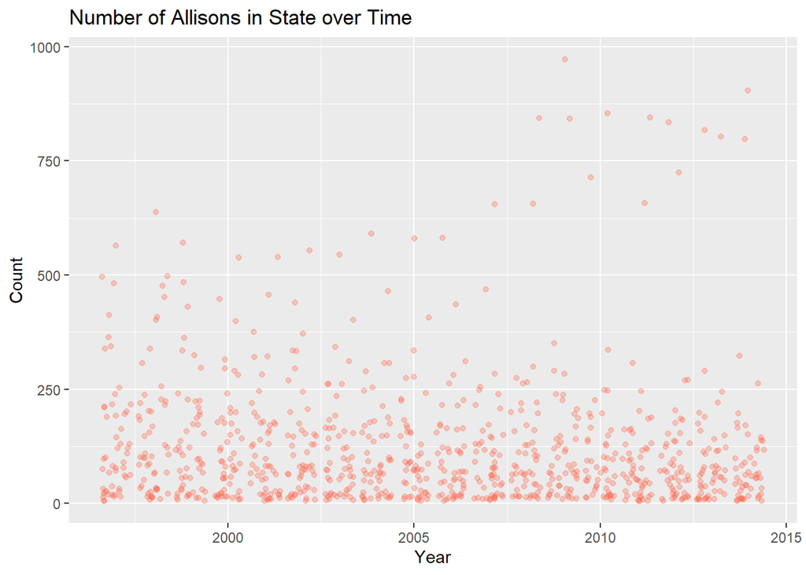

```r
allison_f_year <- allison_f |>
  group_by(State) |>
  replace_na(list('Count' = 0)) |>
  select(Year, State, Count)

ggplot(data = allison_f_year, mapping = aes(x = Year, y = Count)) +
  geom_jitter(alpha = 0.3, color = 'tomato') +
  labs(title = "Number of Allisons in State over Time")
```

## **4 Modeling the Number of Allisons**

4. Fit a linear model with the year as the explanatory variable, and the number of Allisons as the response. Similar to #3, each year should have **one** observation–the total number of Allisons born that year.

   ```r
   allison_lm <- lm(Count ~ Year, data = allison_f)
   ```

5. Write out the estimated regression equation.

   ```r
   tidy(allison_lm)
   ```

   ```
   # A tibble: 2 × 5
     term        estimate std.error statistic p.value
     <chr>          <dbl>     <dbl>     <dbl>   <dbl>
   1 (Intercept)  3894.    1766.         2.21  0.0277
   2 Year           -1.88     0.880     -2.14  0.0328
   ```

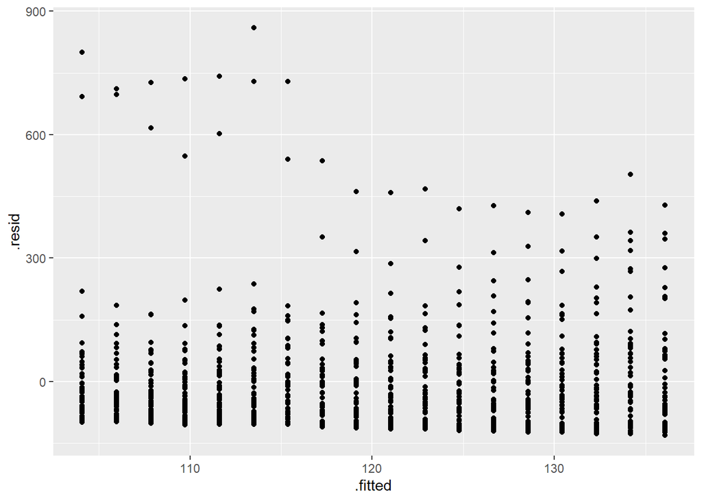

   ```r
   allison_lm |>
     augment() |>
     ggplot(mapping = aes(y = .resid, x = .fitted)) +
     geom_point()
   ```

   It appears that that there is not equal variance present in this model because there are clearly far more outlying positive residuals lying above the least squares line. Additionally, a pattern I can see is that the variance is decreasing as the fitted values increase, as the residual points tend to come closer to 0.
7. What do you conclude from this model? Is my name not cool anymore?

   It is difficult to make conclusions from this model since equal variance is not present.

## **5 Spelling by State**

8. Narrow the A name dataset (downloaded previously) down to only male-assigned babies named “Allan”, “Alan”, or “Allen”. Make a plot comparing the popularity of these names over time.

```r
Aln_data <- StateNames_A |>
  filter(Name == 'Allan' |
         Name == 'Alan' |
         Name == 'Allen') |>
  rename(sex = Gender) |>
  group_by(Name, Year) |>
  summarise(total_count = sum(Count))

Aln_data
```

```
# A tibble: 54 × 3
# Groups:   Name [3]
   Name   Year total_count
   <chr> <dbl>       <dbl>
 1 Alan   1997        2155
 2 Alan   1998        2102
 3 Alan   1999        2220
 4 Alan   2000        2398
 5 Alan   2001        2622
 6 Alan   2002        2591
 7 Alan   2003        3083
 8 Alan   2004        3051
 9 Alan   2005        3189
10 Alan   2006        3442
# … with 44 more rows
```

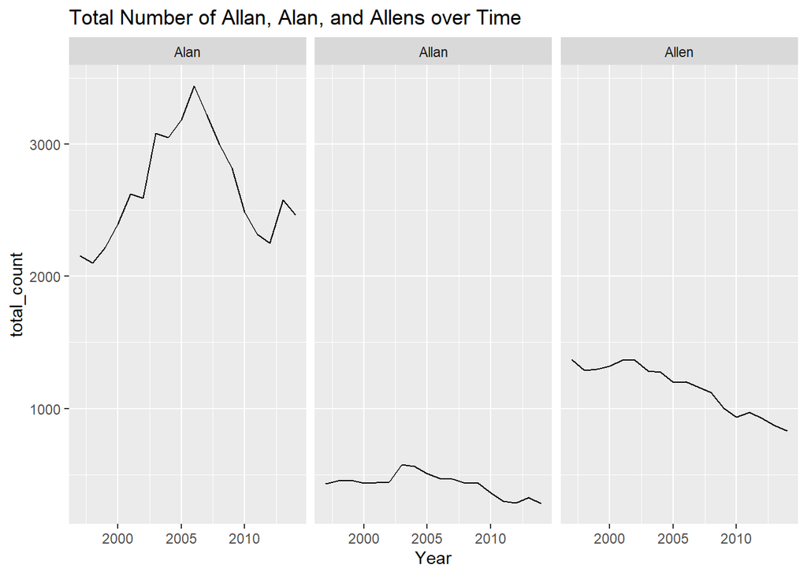

```r
ggplot(data = Aln_data, mapping = aes(x = Year, y = total_count)) +
  geom_line() +
  facet_wrap(~ Name) +
  labs(title = "Total Number of Allan, Alan, and Allens over Time")
```

```r
Aln_prop <- StateNames_A |>
  filter(Name %in% c('Allan', 'Alan', 'Allen'),
           Year == 2000,
           State %in% c('CA', 'PA')
         ) |>
  group_by(Name, State) |>
  summarize(total_count = sum(Count)) |>
  group_by(State) |>
  mutate(Prop = total_count / sum(total_count)) |>
  select(Name, State, Prop) |>
  pivot_wider(names_from = Name, values_from = Prop)
```